# Assignment 5 - Kaggle Competition and Unsupervised Learning

## Daniela Jiménez Lara

Netid: dj216

*Names of students you worked with on this assignment*: Barbara Flores, Shaila Güereca

Note: this assignment falls under collaboration Mode 2: Individual Assignment – Collaboration Permitted. Please refer to the syllabus for additional information.

Instructions for all assignments can be found [here](https://kylebradbury.github.io/ids705/notebooks/assignment_instructions.html).

Total points in the assignment add up to 90; an additional 10 points are allocated to presentation quality.

# Learning objectives

Through completing this assignment you will be able to...

1. Apply the full supervised machine learning pipeline of preprocessing, model selection, model performance evaluation and comparison, and model application to a real-world scale dataset
2. Apply clustering techniques to a variety of datasets with diverse distributional properties, gaining an understanding of their strengths and weaknesses and how to tune model parameters
3. Apply PCA and t-SNE for performing dimensionality reduction and data visualization

# 1

## [40 points] Kaggle Classification Competition

You've learned a great deal about supervised learning and now it's time to bring together all that you've learned. You will be competing in a Kaggle Competition along with the rest of the class! Your goal is to predict hotel reservation cancellations based on a number of potentially related factors such as lead time on the booking, time of year, type of room, special requests made, number of children, etc. While you will be asked to take certain steps along the way to your submission, you're encouraged to try creative solutions to this problem and your choices are wide open for you to make your decisions on how to best make the predictions.

### IMPORTANT: Follow the link posted on Ed to register for the competition

You can view the public leaderboard anytime at the Kaggle website (see the Ed post).

**The Data**. The dataset is provided as `a5_q1.pkl` which is a pickle file format, which allows you to load the data directly using the code below; the data can be downloaded from the Kaggle competition website (see Ed Discussions for the link). A data dictionary for the project can be found [here](https://github.com/rfordatascience/tidytuesday/blob/master/data/2020/2020-02-11/readme.md) and the original paper that describes the dataset can be found [here](https://www.sciencedirect.com/science/article/pii/S2352340918315191). When you load the data, 5 matrices are provided `X_train_original`, `y_train`, and `X_test_original`, which are the original, unprocessed features and labels for the training set and the test features (the test labels are not provided - that's what you're predicting). Additionally, `X_train_ohe` and `X_test_ohe` are provided which are one-hot-encoded (OHE) versions of the data. The OHE versions OHE processed every categorical variable. This is provided for convenience if you find it helpful, but you're welcome to reprocess the original data other ways if your prefer.

**Scoring**. You will need to achieve a minimum acceptable level of performance to demonstrate proficiency with using these supervised learning techniques. Beyond that, it's an open competition and scoring in the top three places of the *private leaderboard* will result in **5 bonus points in this assignment** (and the pride of the class!). Note: the Kaggle leaderboard has a public and private component. The public component is viewable throughout the competition, but the private leaderboard is revealed at the end. When you make a submission, you immediately see your submission on the public leaderboard, but that only represents scoring on a fraction of the total collection of test data, the rest remains hidden until the end of the competition to prevent overfitting to the test data through repeated submissions. You will be be allowed to hand-select two eligible submissions for private score, or by default your best two public scoring submissions will be selected for private scoring.

### Requirements:

**(a) Explore your data.** Review and understand your data. Look at it; read up on what the features represent; think through the application domain; visualize statistics from the paper data to understand any key relationships. **There is no output required for this question**, but you are encouraged to explore the data personally before going further.

**(b) Preprocess your data.** Preprocess your data so it's ready for use for classification and describe what you did and why you did it. Preprocessing may include: normalizing data, handling missing or erroneous values, separating out a validation dataset, preparing categorical variables through one-hot-encoding, etc. To make one step in this process easier, you're provided with a one-hot-encoded version of the data already.

- Comment on each type of preprocessing that you apply and both how and why you apply it.

**(c) Select, train, and compare models.** Fit at least 5 models to the data. Some of these can be experiments with different hyperparameter-tuned versions of the same model, although all 5 should not be the same type of model. There are no constraints on the types of models, but you're encouraged to explore examples we've discussed in class including:

1. Logistic regression
2. K-nearest neighbors
3. Random Forests
4. Neural networks
5. Support Vector Machines
6. Ensembles of models (e.g. model bagging, boosting, or stacking). `Scikit-learn` offers a number of tools for assisting with this including those for [bagging](https://scikit-learn.org/stable/modules/generated/sklearn.ensemble.BaggingClassifier.html#sklearn.ensemble.BaggingClassifier), [boosting](https://scikit-learn.org/stable/modules/generated/sklearn.ensemble.GradientBoostingClassifier.html), and [stacking](https://scikit-learn.org/stable/modules/generated/sklearn.ensemble.StackingClassifier.html). You're also welcome to explore options beyond the `sklean` universe; for example, some of you may have heard of [XGBoost](https://github.com/dmlc/xgboost) which is a very fast implementation of gradient boosted decision trees that also allows for parallelization.

When selecting models, be aware that some models may take far longer than others to train. Monitor your output and plan your time accordingly.

Assess the classification performance AND computational efficiency of the models you selected:

- Plot the ROC curves and PR curves for your models in two plots: one of ROC curves and one of PR curves. For each of these two plots, compare the performance of the models you selected above and trained on the training data, evaluating them on the validation data. Be sure to plot the line representing random guessing on each plot. You should plot all of the model's ROC curves on a single plot and the PR curves on a single plot. One of the models should also be your BEST performing submission on the Kaggle public leaderboard (see below). In the legends of each, include the area under the curve for each model (limit to 3 significant figures). For the ROC curve, this is the AUC; for the PR curve, this is the average precision (AP).
- As you train and validate each model time how long it takes to train and validate in each case and create a plot that shows both the training and prediction time for each model included in the ROC and PR curves.
- Describe:
  - Your process of model selection and hyperparameter tuning
  - Which model performed best and your process for identifying/selecting it

**(d) Apply your model "in practice".** Make *at least* 5 submissions of different model results to the competition (more submissions are encouraged and you can submit up to 5 per day!). These do not need to be the same that you report on above, but you should select your *most competitive* models.

- Produce submissions by applying your model on the test data.
- Be sure to RETRAIN YOUR MODEL ON ALL LABELED TRAINING AND VALIDATION DATA before making your predictions on the test data for submission. This will help to maximize your performance on the test data.
- In order to get full credit on this problem you must achieve an AUC on the Kaggle public leaderboard above the "Benchmark" score on the public leaderboard.

### Guidance:

1. **Preprocessing**. You may need to preprocess the data for some of these models to perform well (scaling inputs or reducing dimensionality). Some of this preprocessing may differ from model to model to achieve the best performance. A helpful tool for creating such preprocessing and model fitting pipelines is the sklearn `pipeline` module which lets you group a series of processing steps together.
2. **Hyperparameters**. Hyperparameters may need to be tuned for some of the model you use. You may want to perform hyperparameter tuning for some of the models. If you experiment with different hyperparameters that include many model runs, you may want to apply them to a small subsample of your overall data before running it on the larger training set to be time efficient (if you do, just make sure to ensure your selected subset is representative of the rest of your data).
3. **Validation data**. You're encouraged to create your own validation dataset for comparing model performance; without this, there's a significant likelihood of overfitting to the data. A common choice of the split is 80% training, 20% validation. Before you make your final predictions on the test data, be sure to retrain your model on the entire dataset.
4. **Training time**. This is a larger dataset than you've worked with previously in this class, so training times may be higher that what you've experienced in the past. Plan ahead and get your model pipeline working early so you can experiment with the models you use for this problem and have time to let them run.

### Starter code

Below is some code for (1) loading the data and (2) once you have predictions in the form of confidence scores for those classifiers, to produce submission files for Kaggle.

```python
import pandas as pd
import numpy as np
import pickle

################################
# Load the data
################################
data = pd.read_pickle("./data/a5_q1.pkl")

y_train = data["y_train"]
X_train_original = data["X_train"]  # Original dataset
X_train_ohe = data["X_train_ohe"]  # One-hot-encoded dataset

X_test_original = data["X_test"]
X_test_ohe = data["X_test_ohe"]

################################
# Produce submission
################################


def create_submission(confidence_scores, save_path):
    """Creates an output file of submissions for Kaggle

    Parameters
    ----------
    confidence_scores : list or numpy array
        Confidence scores (from predict_proba methods from classifiers) or
        binary predictions (only recommended in cases when predict_proba is
        not available)
    save_path : string
        File path for where to save the submission file.

    Example:
    create_submission(my_confidence_scores, './data/submission.csv')

    """
    import pandas as pd

    submission = pd.DataFrame({"score": confidence_scores})
    submission.to_csv(save_path, index_label="id")
```

**ANSWER**

**a)**

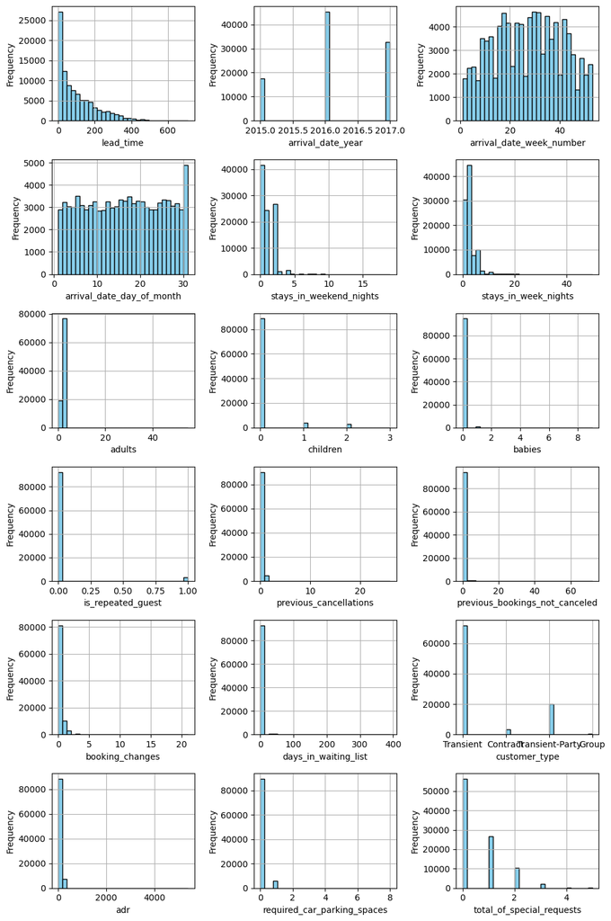

```python
import matplotlib.pyplot as plt
import pandas as pd

num_vars = [
    "lead_time",
    "arrival_date_year",
    "arrival_date_week_number",
    "arrival_date_day_of_month",
    "stays_in_weekend_nights",
    "stays_in_week_nights",
    "adults",
    "children",
    "babies",
    "is_repeated_guest",
    "previous_cancellations",
    "previous_bookings_not_canceled",
    "booking_changes",
    "days_in_waiting_list",
    "customer_type",
    "adr",
    "required_car_parking_spaces",
    "total_of_special_requests",
]

char_vars = [
    "hotel",
    "arrival_date_month",
    "meal",
    "country",
    "market_segment",
    "distribution_channel",
    "reserved_room_type",
    "assigned_room_type",
    "deposit_type",
    "agent",
    "company",
    "customer_type",
]


# Create a grid of histograms
num_rows = 6
num_cols = 3
fig, axs = plt.subplots(num_rows, num_cols, figsize=(10, 15))

axs = axs.flatten()

for i, column_name in enumerate(num_vars):
    ax = axs[i]
    ax.hist(X_train_original[column_name], bins=30, color="skyblue", edgecolor="black")
    ax.set_xlabel(column_name)
    ax.set_ylabel("Frequency")
    ax.grid(True)

plt.tight_layout()
plt.show()
```

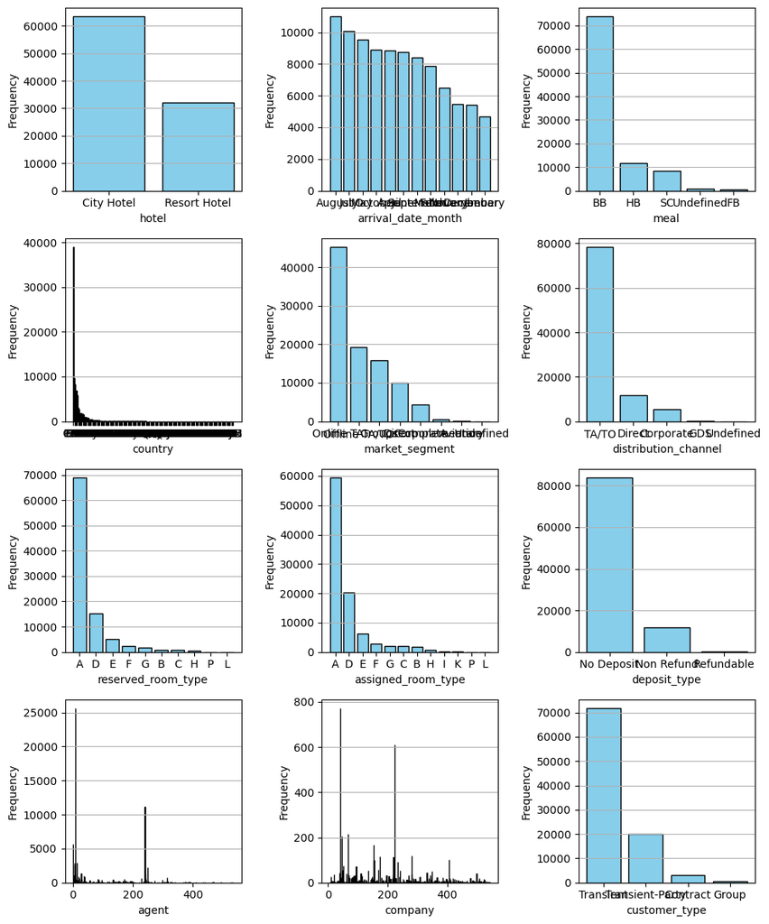

```python
num_rows = 4
num_cols = 3

fig, axs = plt.subplots(num_rows, num_cols, figsize=(10, 12))
axs = axs.flatten()

for i, column_name in enumerate(char_vars):
    ax = axs[i]
    values = X_train_original[column_name].value_counts()
    ax.bar(values.index, values.values, color="skyblue", edgecolor="black")
    ax.set_xlabel(column_name)
    ax.set_ylabel("Frequency")
    ax.grid(axis="y")

# Adjust layout
plt.tight_layout()
plt.show()
```

```python
X_train_original.info()
```

```
<class 'pandas.core.frame.DataFrame'>
Index: 95512 entries, 0 to 119389
Data columns (total 29 columns):
 #   Column                          Non-Null Count  Dtype
---  ------                          --------------  -----
 0   hotel                           95512 non-null  object
 1   lead_time                       95512 non-null  int64
 2   arrival_date_year               95512 non-null  int64
 3   arrival_date_month              95512 non-null  object
 4   arrival_date_week_number        95512 non-null  int64
 5   arrival_date_day_of_month       95512 non-null  int64
 6   stays_in_weekend_nights         95512 non-null  int64
 7   stays_in_week_nights            95512 non-null  int64
 8   adults                          95512 non-null  int64
 9   children                        95510 non-null  float64
```

[output cut: 21 more lines]

**(c) Select, train, and compare models.**

#### Logistic Regression

```python
import sklearn
from sklearn.model_selection import train_test_split
from sklearn.linear_model import LogisticRegression

# from sklearn.metrics import log_loss

data = pd.read_pickle("./data/a5_q1.pkl")


y_train = data["y_train"]
X_train_original = data["X_train"]  # Original dataset
X_train_ohe = data["X_train_ohe"]  # One-hot-encoded dataset

X_test_original = data["X_test"]
X_test_ohe = data["X_test_ohe"]


X_train_ohe = X_train_ohe.fillna(0)
X_test_ohe = X_test_ohe.fillna(0)

X_train_80, X_train_20, y_train_80, y_train_20 = train_test_split(
    X_train_ohe, y_train, test_size=0.2, random_state=42
)
```

```python
from sklearn.model_selection import RandomizedSearchCV
import warnings

warnings.simplefilter("ignore")
param_dist = {
    "C": np.logspace(-4, 4, 20),
    "penalty": ["l1", "l2"],
    "solver": ["liblinear", "saga"],
}
lgr_rc = LogisticRegression()
# Perform randomized search cross-validation
random_search = RandomizedSearchCV(
    estimator=lgr_rc, param_distributions=param_dist, n_iter=10, cv=5
)
random_search.fit(X_train_80, y_train_80)

# Print the best hyperparameters
print("Best hyperparameters:", random_search.best_params_)
```

```
Best hyperparameters: {'solver': 'liblinear', 'penalty': 'l1', 'C': 78.47599703514607}
```

```python
from sklearn.metrics import roc_curve, roc_auc_score

# Logistic regression
from sklearn.linear_model import LogisticRegression

# .fillna

lgr = LogisticRegression(
    random_state=0,
    solver="liblinear",
    penalty="l1",
    C=78.475,
    max_iter=2500,
).fit(X_train_80, y_train_80)

y_prob_lgr = lgr.predict_proba(X_train_20)[:, 1]
y_pred_lgr = lgr.predict(X_train_20)[:, 1]

fpr_lgr, tpr_lgr, th_lgr = roc_curve(y_train_20, y_prob_lgr)
auc_score_lgr = roc_auc_score(y_train_20, y_prob_lgr)


print("AUC_score validation", auc_score_lgr)
```

[output not shown]

```python
print("Run time on train: 1s")
print("Run time on validation: 1.5s")

run_time_train = {"lgr": 1}
run_time_validation = {"lgr": 1.5}
```

```
Run time on train: 1s
Run time on validation: 1.5s
```

#### Random Forest

```python
# random forrest with feature selecction
from sklearn.feature_selection import SelectFromModel
from sklearn.ensemble import RandomForestClassifier

rfo = RandomForestClassifier(n_estimators=2000)

sfm = SelectFromModel(rfo, threshold=0.000100)
sfm.fit(X_train_80, y_train_80)

# Transform the data to select features
X_train_80_fs = sfm.transform(X_train_80)
X_train_20_fs = sfm.transform(X_train_20)
```

```python
from sklearn.metrics import roc_curve, roc_auc_score

rf_fs = RandomForestClassifier(n_estimators=2000)
rf_fs.fit(X_train_80_fs, y_train_80)

y_prob_rf_fs = rf_fs.predict_proba(X_train_20_fs)[:, 1]
y_pred_rf_fs = rf_fs.predict(X_train_20_fs)

fpr_rf_fs, tpr_rf_fs, th_rf_fs = roc_curve(y_train_20, y_prob_rf_fs)

auc_score_rf_fs = roc_auc_score(y_train_20, y_prob_rf_fs)

fpr_rf_fs, tpr_rf_fs, th_rf_fs = roc_curve(y_train_20, y_prob_rf_fs)

auc_score_rf_fs = roc_auc_score(y_train_20, y_prob_rf_fs)
print("AUC_score validation RF with feature selection", auc_score_rf_fs)
```

```
AUC_score validation RF with feature selection 0.9593597495866963
```

```python
print("Run time on train: 2m 46s")
print("Run time validation: 10 m 12 s")

run_time_train["RF"] = 166
run_time_validation["RF"] = 612
```

```
Run time on train: 2m 46s
Run time validation: 10 m 12 s
```

#### K-nearest neighbors

```python
from sklearn.neighbors import KNeighborsClassifier

neigh = KNeighborsClassifier(n_neighbors=3)
neigh.fit(X_train_80, y_train_80)

y_prob_ne = neigh.predict_proba(X_train_20)[:, 1]
y_pred_ne = neigh.predict(X_train_20)
fpr_ne, tpr_ne, th_ne = roc_curve(y_train_20, y_prob_ne)

auc_score_ne = roc_auc_score(y_train_20, y_prob_ne)
```

```python
print("Run time  train: 14m 30s")
print("Run time validation: 3s ")

run_time_train["KNN"] = 870
run_time_validation["KNN"] = 3
```

```
Run time  train: 14m 30s
Run time validation: 3s
```

```python
#### Neural networks
from sklearn.neural_network import MLPClassifier
from scipy.stats import loguniform
import warnings

warnings.simplefilter("ignore")

# bz_list = [20, 50, 100, 250, 500]
lr_log_list = loguniform(1e-5, 1e0).rvs(20)
# rp_log_list = loguniform(1e-8, 1e2).rvs(20)


param_dict = {
    "learning_rate_init": lr_log_list,
}

mcv2 = MLPClassifier()

random_search = RandomizedSearchCV(
    estimator=mcv2,
    param_distributions=param_dict,
    n_iter=10,
    scoring="roc_auc",
    cv=3,
    random_state=1,
    n_jobs=-1,
)

random_search.fit(X_train_80, y_train_80)

print("Best hyperparameters:", random_search.best_params_)
```

```
Best hyperparameters: {'learning_rate_init': 0.008368229549763117}
```

```python
mlp = MLPClassifier(random_state=1, learning_rate_init=0.008368229549763117).fit(
    X_train_80, y_train_80
)
```

```python
y_prob_mlp = mlp.predict_proba(X_train_20)[:, 1]
y_pred_mlp = mlp.predict(X_train_20)
fpr_mlp, tpr_mlp, th_mlp = roc_curve(y_train_20, y_prob_mlp)

auc_score_mlp = roc_auc_score(y_train_20, y_prob_mlp)

auc_score_mlp
```

```
0.9254578239087662
```